# TzeFungLung_Assign15

jim lung

12-7-2017

# Data 605 Assignment 15

## 1. Find the equation of the regression line for the given points. Round any final values to the nearest hundredth, if necessary:

## ( 5.6, 8.8 ), ( 6.3, 12.4 ), ( 7, 14.8 ), ( 7.7, 18.2 ), ( 8.4, 20.8 )

```r
# Create the predictor and response variable.
x <- c(5.6, 6.3, 7, 7.7, 8.4)
y <- c(8.8, 12.4, 14.8, 18.2, 20.8)
relation <- lm(y~x)
summary(relation)
```

```
##
## Call:
## lm(formula = y ~ x)
##
## Residuals:
##     1     2     3     4     5
## -0.24  0.38 -0.20  0.22 -0.16
##
## Coefficients:
##             Estimate Std. Error t value Pr(>|t|)
## (Intercept) -14.8000     1.0365  -14.28 0.000744 ***
## x             4.2571     0.1466   29.04 8.97e-05 ***
## ---
## Signif. codes:  0 '***' 0.001 '**' 0.01 '*' 0.05 '.' 0.1 ' ' 1
##
## Residual standard error: 0.3246 on 3 degrees of freedom
## Multiple R-squared:  0.9965, Adjusted R-squared:  0.9953
## F-statistic: 843.1 on 1 and 3 DF,  p-value: 8.971e-05
```

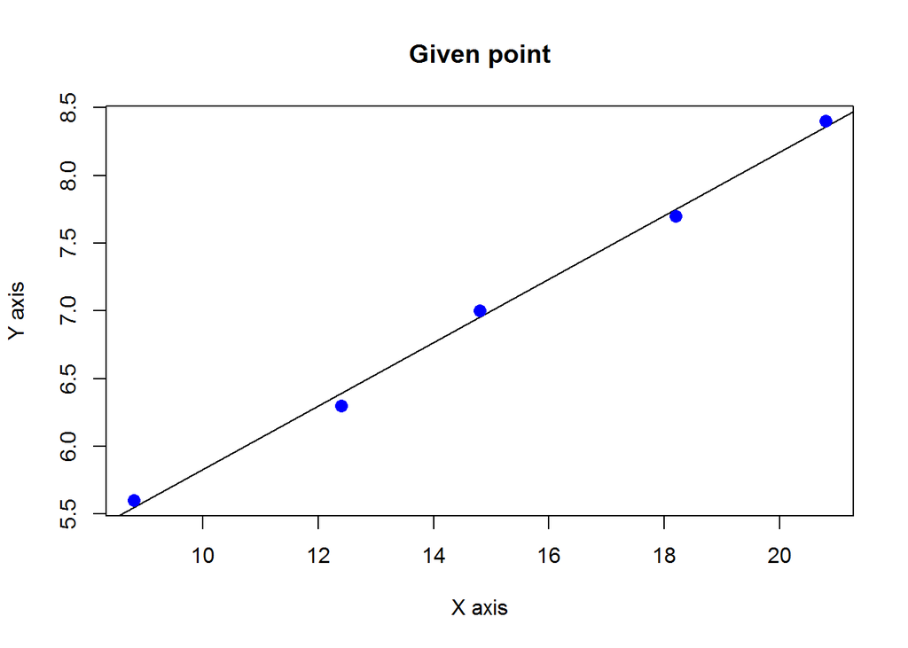

```r
# Plot the chart.
plot(y,x,col = "blue",main = "Given point",
abline(lm(x~y)),cex = 1.3,pch = 16,xlab = "X axis",ylab = "Y axis")
```

## 2. Find all local maxima, local minima, and saddle points for the function given below. Write your answer(s) in the form ( x, y, z ). Separate multiple points with a comma.

$f(x,y)=24x - 6xy^2 -8y^3$

first order and second order partial derivatives:

$f_{x}=24 - 6y^2$

$f_{y}= - 12xy -24y^2$

$f_{xx}= 0$

$f_{yy}= - 12x -48y$

$f_{xy}= - 12y$

when $f_{x} = 0 ,\ f_{y}=0$ Critical points:

$f_{x}=24 - 6y^2 = 0$

$y^2 = 4$

$y = 2 \ or -2$

$f_{y}= - 12xy -24y^2 = 0$

$- xy -2y^2 = 0$

when $y = 2, x = -2y , x = -4 $

when $y = -2, x = -2y , x = 4 $

So we have critical point (4, -2) and (-4, 2).

Using the Second Derivative Test:

$D = D(a,b) = f_{xx}(a,b) f_{yy}(a,b) - f_{xy}(a,b)^2 $

saddle point: D > 0 is max or D < 0 is min

$f_{xx}= 0, \ f_{yy}= - 12x -48y, \ f_{xy}= - 12y$

$D = (0)*(- 12x -48y)-(- 12y)^2 = -144y^2$

at (4, -2)

$D = -576 < 0$

at (-4, 2)

$D = -576 < 0$

we classify (4, -2) and (-4, 2) to be saddle point.

## 3. A grocery store sells two brands of a product, the “house” brand and a “name” brand. The manager estimates that if she sells the “house” brand for x dollars and the “name” brand for y dollars, she will be able to sell 81 - 21 x + 17 y units of the “house” brand and 40 + 11 x - 23 y units of the “name” brand.

Step 1. Find the revenue function R ( x, y ).

Revenue for House brand: $R(x) = x*(81 - 21x + 17y)$

Revenue for name brand: $R(y) = y*(40 + 11x - 23y)$

Total Revenue: $R(x,y)= x*(81 - 21x + 17y) + y*(40 + 11x - 23y)$

$R(x,y)= 81x - 21x^2 + 17xy + 40y + 11xy - 23y^2$

$R(x,y)= - 21x^2 - 23y^2 + 28xy + 81x + 40y $

Step 2. What is the revenue if she sells the “house” brand for $2.30 and the “name” brand for $4.10?

Find R(2.3, 4.1):

```r
x <- 2.3
y <- 4.1

z <- -21*(x^2) - 23*(y^2) + 28*x*y + 81*x +40*y
z
```

```
## [1] 116.62
```

The revenue is 116.62

## 4.

A company has a plant in Los Angeles and a plant in Denver. The firm is committed to produce a total of 96 units of a product each week. The total weekly cost is given by $C(x,y) = \frac{1}{6} x^2 + \frac{1}{6} y^2 + 7x + 25y + 700$ , where x is the number of units produced in Los Angeles and y is the number of units produced in Denver. How many units should be produced in each plant to minimize the total weekly cost?

Total unit per week = 96 units Number of LA = x Number of Denver = y

$ x + y = 96$

$ y = 96-x $

When $ y = 96-x $ in equation:

$C(x,y) = \frac{1}{6} x^2 + \frac{1}{6} y^2 + 7x + 25y + 700$

$ = x^2 + (96 - x)^2 + 7x + 25(96-x) + 700$

$ = x^2 + 1536 - 32x + + 7x + 2400 - 25x + 700$

$ = x^2 - 50x + 4636$

Minima critical point : $C'(x) = 0$

$C'(x) = \frac{2}{3} x - 50 = 0$

$ x = 75$

when $ x = 75$ in $ x + y = 96$:

$ y = 21 $

Minimize the cost should be 75 units in LA, 21 unit in Denver.

## 5.

Evaluate the double integral on the given region.

$\int \int_R (e^{8x + 3y}) dA; R: 2 \leq x \leq 4 \ { and } \ 2 \leq y \leq 4$

Write your answer in exact form without decimals.

$= \int_{2}^{4} \int_{2}^{4} (e^{8x}e^{3y}) \ dx \ dy$

$= \int_{2}^{4} \int_{2}^{4} (e^{8x}e^{3y}) \ dx \ dy$

$=\int_{2}^{4} \frac{1}{8}e^{3y+32}-\frac{1}{8}e^{3y+16} \ dy$

$=\int_{2}^{4} \frac{1}{8}\left(e^{16}-1\right)e^{3y+16} \ dy$

$=\frac{e^{44}-e^{28}}{24}-\frac{e^{38}-e^{22}}{24}$

$=\frac{1}{24}\left(e^{22}-e^{28}-e^{38}+e^{44}\right)$